# MAA204-Homework sources code

## Introduction

This is the source code of MAA204-Introduction to Statistics at Ecole Polytechnique Bachelor of Science program, from Yubo Cai.

## Question 4

On R, read the file **exponential.csv**. Then compare through a plot the distribution of the dataset observations and the distribution of the exponential random variable with the estimated parameter $\hat{m}_{\mathrm{ML}}$

```
       x
 Min.   :0.0004254
 1st Qu.:0.1014974
 Median :0.2222739
 Mean   :0.3256294
 3rd Qu.:0.4169742
 Max.   :2.5573967
```

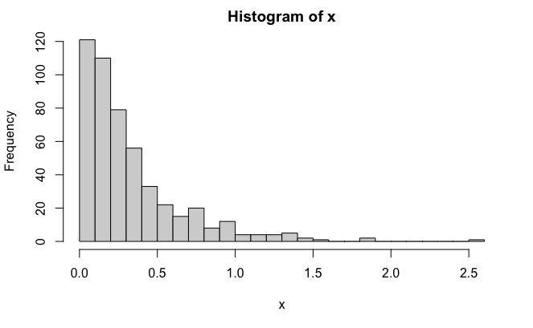

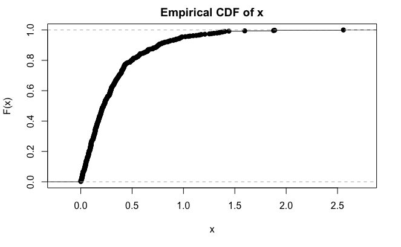

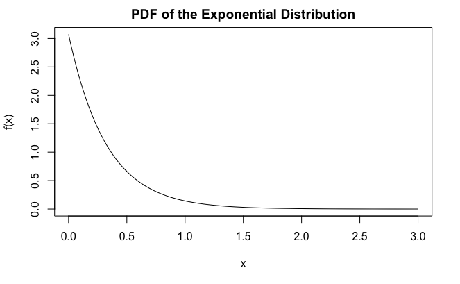

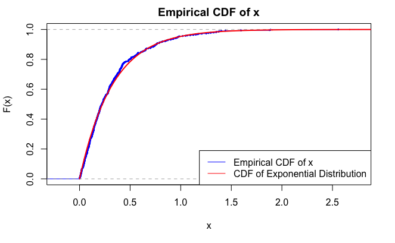

## Question 10

For large $n=10^{5}$, simulate the random variable $Z_{n}$ and compare it to its asymptotic distribution (you can choose any value of $m$)

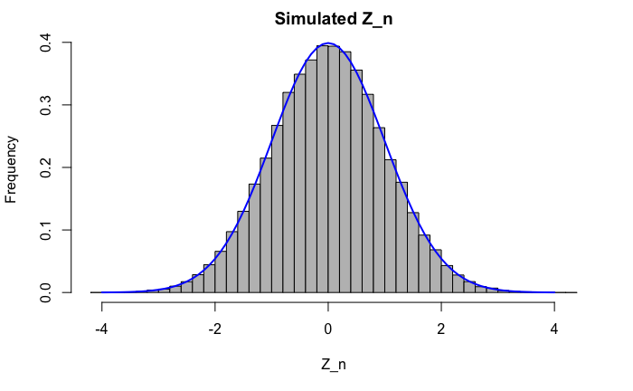

## Question 18

We will now empirically test the Bow-Muller method. Generate 3000 samples of U and V i.i.d. following a uniform law in $[0,1]$, then $X$ and $Y$ according to the Box-Muller method. Plot the histograms of both functions and compute the covariance between $X$ and $Y$. Generate 3000 samples using the rnorm function of R. Comment each results.

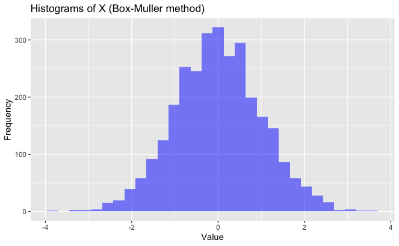

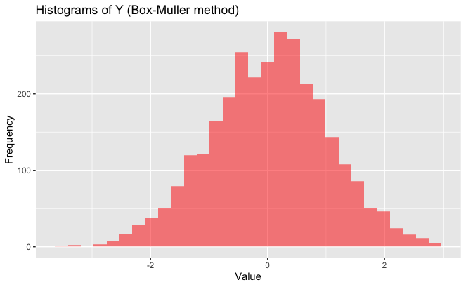

```
[1] -0.008461388
```

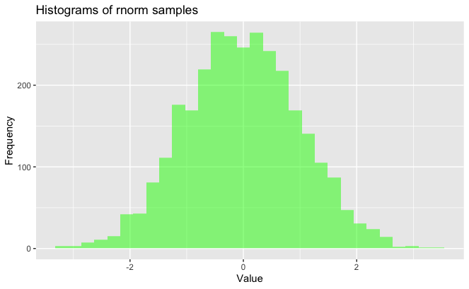

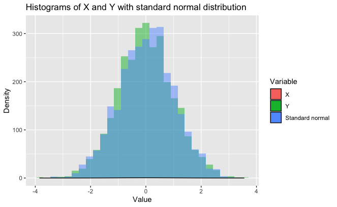

## Question 19

A common way to compare two distributions is through a quantile-quantile diagram. Generate $N 1, N 2$ two vectors of 3000 sample of a normal distribution using the funntion rnorm, and $E 1, E 2$ a vector of 3000 samples of an exponential distribution using the function rexp. Plot the quantile-quantile diagrams of $N 1$ and $N 2$, then of $E 1$ and $E 2$. What do you observe? Now plot the diagram of $N 1$ and $E 1$. How do you interpret the changes? (you may type help(qqplot) in the console to get information on the syntax and the procedure).

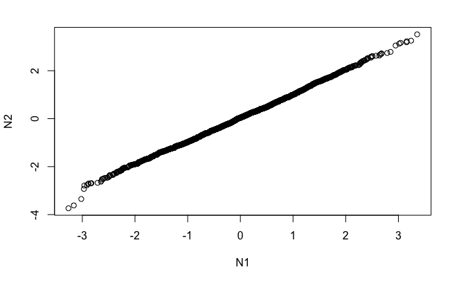

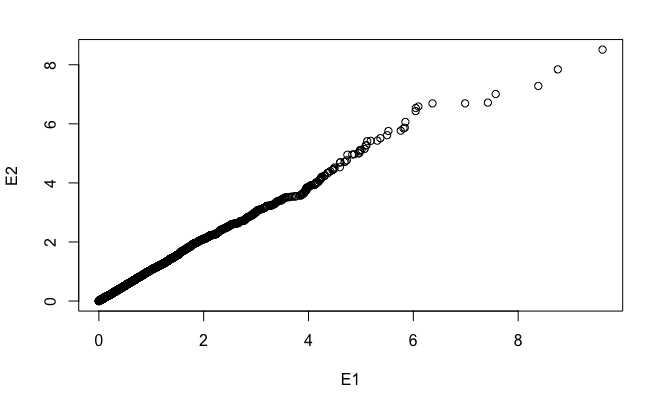

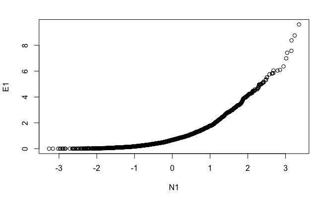

## Question 20

Draw the qqplot of the samples generated through the Box Muller method with the exponentially distributed samples first, then the normally distributed ones. Conclude.

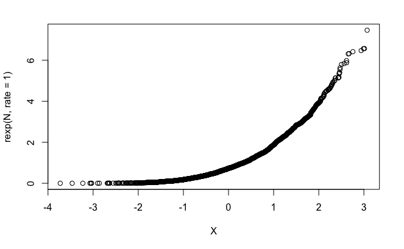

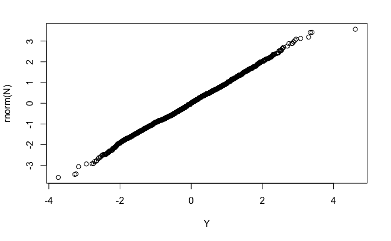